# WIE2003 Group Assignment Report - Predict Your Grade

Make same graph for **Guardian** which is same what did with **Sex** column before

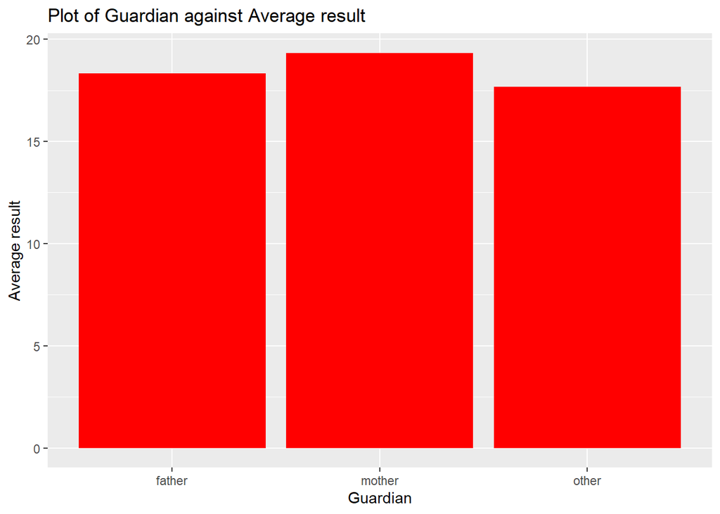

```r
data2 <- data.frame(Guardian = d1$Guardian, Average.result = d1$Average.result)
p2 <- ggplot(data2) + geom_col(aes(x=Guardian, y=Average.result), position="dodge", fill = "red")
p2 <- p2 + labs(title="Plot of Guardian against Average result", x="Guardian", y="Average result")
p2
```

∴ There is insignificant difference for the three **Guardian** attributes with the **“Average result”**, removing **Guardian** column is required

Removing columns **Sex**, **Guardian**, **Mother’s job**, and **Father’s job**

```r
d1 <- d1[-c(1, 8, 9, 10)]
```

Final checking on data processed

```r
summary(d1)
```

```
##       Age       Address Family.size Parent.s.cohabition.status
##  Min.   :15.0   R: 88   GT3:281     A: 41
##  1st Qu.:16.0   U:307   LE3:114     T:354
##  Median :17.0
##  Mean   :16.7
##  3rd Qu.:18.0
##  Max.   :22.0
##  Mother.s.education Father.s.education Time.from.home.to.school
##  0:  3              0:  2              1:257
##  1: 59              1: 82              2:107
##  2:103              2:115              3: 23
##  3: 99              3:100              4:  8
##  4:131              4: 96
##
##  Weekly.study.time Number.of.past.class.failures Extra.educational.support
##  1:105             0:312                         FALSE:344
##  2:198             1: 50                         TRUE : 51
##  3: 65             2: 17
##  4: 27             3: 16
##
##
##  Family.educational.support Extra.paid.class Extra.curricular.activity
##  FALSE:153                  FALSE:214        FALSE:194
##  TRUE :242                  TRUE :181        TRUE :201
##
##
##
##
##  Attended.nursery.school Aims.for.higher.education Internet.access
##  FALSE: 81               FALSE: 20                 FALSE: 66
##  TRUE :314               TRUE :375                 TRUE :329
##
##
##
##
##  In.romantic.relationship Evaluation.for.family.relationship
##  FALSE:263                1:  8
##  TRUE :132                2: 18
##                           3: 68
##                           4:195
##                           5:106
##
##  Evaluation.for.free.time.after.school Frequent.going.out.with.friends
##  1: 19                                 1: 23
##  2: 64                                 2:103
##  3:157                                 3:130
##  4:115                                 4: 86
##  5: 40                                 5: 53
##
##  Current.health.status Number.of.school.absences Average.result
##  1: 47                 Min.   : 0.000            Min.   : 1.333
##  2: 45                 1st Qu.: 0.000            1st Qu.: 8.333
##  3: 91                 Median : 4.000            Median :10.667
##  4: 66                 Mean   : 5.709            Mean   :10.679
##  5:146                 3rd Qu.: 8.000            3rd Qu.:13.333
##                        Max.   :75.000            Max.   :19.333
```

Write the data set where index row won’t be recorded to be stored as another csv, *“Cleaned.csv”*

```r
write.csv(d1, "Cleaned.csv", row.names = FALSE)
```

## Feature Extraction

Obtain the features that is needed to train the **Random Forest Model**. **as.factor()** is used to convert the variables to be **categorical/ factor variables** which is the same as the data set processed before

```r
ds <- read.csv("Cleaned.csv", header=TRUE)

ds.model <- data.frame(
    Age = ds$Age,
    Time.from.home.to.school = as.factor(ds$Time.from.home.to.school),
    Number.of.past.class.failures = as.factor(ds$Number.of.past.class.failures),
    Extra.educational.support = as.factor(ds$Extra.educational.support),
    Family.educational.support = as.factor(ds$Family.educational.support),
    Extra.paid.class = as.factor(ds$Extra.paid.class),
    Extra.curricular.activity = as.factor(ds$Extra.curricular.activity),
    Attended.nursery.school = as.factor(ds$Attended.nursery.school),
    Aims.for.higher.education = as.factor(ds$Aims.for.higher.education),
    Internet.access = as.factor(ds$Internet.access),
    In.romantic.relationship = as.factor(ds$In.romantic.relationship),
    Average.result = ds$Average.result)
```

## Building Prediction Model

Since the average result is a type of **continuous variable**, therefore it is clearly to use **supervised learning regression model**. There are several regression model can be used for our prediction. We choose **Random Forest Regression model** to predict the average result. Random Forest Regression model is an ensemble learning with multiple decision tree. It has the advantages on dealing with non-linearity.

The data set obtained from the feature extraction is split into two, which used for *training (70%) and testing (30%)*. Based on our testing set result, the prediction model has a **root mean square error (rmse) between 3 to 4**, which is relatively moderate.

```r
# Load dplyr library
library(dplyr)

# Load randomForest library to use the model
library(randomForest)

# Split the ds.model to train data frame and test data frame
dt <- sort(sample(nrow(ds.model), nrow(ds.model)*0.7))
train <- ds.model[dt,]
test <- ds.model[-dt,]

# Remove the average result from the test data frame
test <- select(test, -Average.result)

# Train the Random Forest model
model <- randomForest(formula=Average.result ~., data=train)

# Finding root mean square error
actual <- select(ds.model[-dt,], Average.result)
names(actual) <- "actual"
predicted <- predict(model, test)
cal_df <- cbind(actual, predicted)
cal_df$error <- cal_df$actual - cal_df$predicted
rmse <- sqrt(mean(cal_df$error^2))
rmse
```

```
## [1] 3.510534
```

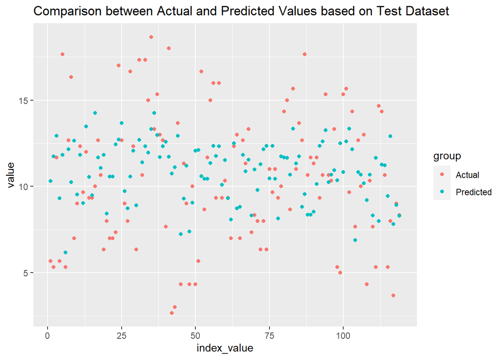

```r
# Plot to see the difference between the actual and predicted based on test set
value <- select(cal_df, actual)
names(value) <- "value"
index_value <- c(1:nrow(value))
group <- "Actual"
actual_df <- cbind(value, index_value, group)
value <- select(cal_df, predicted)
names(value) <- "value"
index_value <- c(1:nrow(value))
group <- "Predicted"
predicted_df <- cbind(value, index_value, group)
plot_df <- rbind(actual_df, predicted_df)
ggplot(plot_df, aes(index_value, value, colour=group)) + geom_point() + ggtitle("Comparison between Actual and Predicted Values based on Test Dataset")
```

## Application development

app.R is split into 2 parts, which are ui, in charge of visualizing the dashboard, and server, in charge of manipulation of input and displaying output. There is a total of *3 tabs* for the shiny app we have created, first to be **“About”**, where descriptions of the variable stored and questions proposed would be listed there. Second tab is **“Graph”**, where a jitter/ scatter graph would be shown, based on input by users on X-axis, Y-axis, facet row and also facet column. The last tab is **“Prediction”**, where users can manipulate for conditions according to their likes to predict average result of the student under the selected conditions. Root mean square error for the prediction and a graph showing the difference between prediction and actual results would be shown as well. *Shinydashboard* library is used in beautify the visualization of the product.

Link to the web application: https://limweiyeong99.shinyapps.io/grade/

Below show for the source code of app.R

```r
library(dplyr)
library(ggplot2)
library(randomForest)
library(rsconnect)
library(shiny)
library(shinydashboard)

# Read data set that is processed and cleaned
ds <- read.csv("Cleaned.csv", header=TRUE)

# Data dictionary
Feature <- names(ds)
Description <- c(
    "student's age (numeric: from 15 to 22)",
    "student's home address type (binary: U - urban or R - rural)",
    "family size (binary: LE3 - less or equal to 3 or GT3 - greater than 3)",
    "parent's cohabitation status (binary: T - living together or A - apart)",
    "mother's education (numeric: 0 - none,  1 - primary education (4th grade), 2 - 5th to 9th grade, 3 - secondary education or 4 - higher education)",
    "father's education (numeric: 0 - none,  1 - primary education (4th grade), 2 - 5th to 9th grade, 3 - secondary education or 4 - higher education)",
    "home to school travel time (numeric: 1 - <15 min., 2 - 15 to 30 min., 3 - 30 min. to 1 hour, or 4 - >1 hour)",
    "weekly study time (numeric: 1 - <2 hours, 2 - 2 to 5 hours, 3 - 5 to 10 hours, or 4 - >10 hours)",
    "number of past class failures (numeric: n for 0<= n <=3)",
    "extra educational support (binary: yes or no)",
    "family educational support (binary: yes or no)",
    "extra paid classes within the subject (binary: yes or no)",
    "extra-curricular activities (binary: yes or no)",
    "attended nursery school (binary: yes or no)",
    "wants to take higher education (binary: yes or no)",
    "Internet access at home (binary: yes or no)",
    "in a romantic relationship (binary: yes or no)",
    "quality of family relationships (numeric: from 1 - very bad to 5 - excellent)",
    "free time after school (numeric: from 1 - very low to 5 - very high)",
    "going out with friends (numeric: from 1 - very low to 5 - very high)",
    "current health status (numeric: from 1 - very bad to 5 - very good)",
    "number of school absences (numeric: from 0 to 93)",
    "average result for the subject within 3 period (continuos: 0 to 20)"
)
dict <- cbind(Feature, Description)

# Obtain the features that is needed to train the Random Forest Model
ds.model <- data.frame(
    Age = ds$Age,
    Time.from.home.to.school = as.factor(ds$Time.from.home.to.school),
    Number.of.past.class.failures = as.factor(ds$Number.of.past.class.failures),
    Extra.educational.support = as.factor(ds$Extra.educational.support),
    Family.educational.support = as.factor(ds$Family.educational.support),
    Extra.paid.class = as.factor(ds$Extra.paid.class),
    Extra.curricular.activity = as.factor(ds$Extra.curricular.activity),
    Attended.nursery.school = as.factor(ds$Attended.nursery.school),
    Aims.for.higher.education = as.factor(ds$Aims.for.higher.education),
    Internet.access = as.factor(ds$Internet.access),
    In.romantic.relationship = as.factor(ds$In.romantic.relationship),
    Average.result = ds$Average.result)

# Split the ds.model to train dataframe and test dataframe
dt <- sort(sample(nrow(ds.model), nrow(ds.model)*0.7))
train <- ds.model[dt,]
test <- ds.model[-dt,]

# Remove the average result from the test data frame
test <- select(test, -Average.result)

# Train the Random Forest model
model <- randomForest(formula=Average.result ~., data=train)

# Finding root mean square error
actual <- select(ds.model[-dt,], Average.result)
names(actual) <- "actual"
predicted <- predict(model, test)
cal_df <- cbind(actual, predicted)
cal_df$error <- cal_df$actual - cal_df$predicted
rmse <- sqrt(mean(cal_df$error^2))

# Plot to see the difference between the actual and predicted based on test set
value <- select(cal_df, actual)
names(value) <- "value"
index_value <- c(1:nrow(value))
group <- "Actual"
actual_df <- cbind(value, index_value, group)
value <- select(cal_df, predicted)
names(value) <- "value"
index_value <- c(1:nrow(value))
group <- "Predicted"
predicted_df <- cbind(value, index_value, group)
plot_df <- rbind(actual_df, predicted_df)

ui <- dashboardPage(
    title = "Predict your grade",
    skin = "purple",
    dashboardHeader(title = "Predict Your Grade"),
    dashboardSidebar(
        sidebarMenu(
            menuItem("About", tabName = "about", icon = icon("info")),
            menuItem("Graph", tabName = "graph", icon = icon("chart-bar")),
            menuItem("Prediction", tabName = "prediction", icon = icon("smile-wink"))
        )
    ),
    dashboardBody(
        tabItems(
            # First tab content
            tabItem(tabName = "about",
                    fluidRow(
                        box(
                            width = 12,
                            title = "Questions",
                            h4("i.   What are the factors that can affect grade of students?"),
                            h4("ii.  How much do these factors affect grade of the students?"),
                            h4("iii. What is the relationship between these factors?")
                        )
                    ),
                    fluidRow(
                        box(
                            width = 12,
                            title = "Data Dictionary",
                            tableOutput("details")
                        )
                    ),
                    fluidRow(
                        box(
                            width = 12,
                            title = "Want to understand more?",
                            a("Click here to Github", href="https://github.com/YeongLIM99/grade")
                        )
                    )
            ),
            tabItem(tabName = "graph",
                    fluidRow(
                        box(
                            title = "Parameter",
                            sliderInput("Population", "Choose number of students", min = 30, max = 395, value = 200),
                            # Below are inputs for graph
                            selectInput("x_axis", "Choose for X-axis", choices=names(ds), selected=names(ds)[1]),
                            selectInput("y_axis", "Choose for Y-axis", choices=names(ds), selected=names(ds)[2]),
                            # None would be represented with "." in syntax, where there will be no chosen variable
                            selectInput('facet_row', 'Choose the facet row', choices=c(None='.', names(ds))),
                            selectInput('facet_col', 'Choose the facet column', choices=c(None='.', names(ds)))
                        ),
                        box(
                            title = h1("Plot for variables"),
                            plotOutput("graph"),
                            helpText("Please refer to About for more information.")
                        )
                    )
```

```r
            ),
            tabItem(tabName = "prediction",
                    fluidRow(
                        box(
                            title = "Parameter",
                            # Below are inputs for prediction
                            checkboxGroupInput('check_box', 'Select the variable(s) to be TRUE',
                                               choiceNames=c('Extra.educational.support','Family.educational.support','Extra.paid.class',
                                                             'Extra.curricular.activity', 'Attended.nursery.school', 'Aims.for.higher.education',
                                                             'Internet.access', 'In.romantic.relationship'),
                                               choiceValues=c('Extra.educational.support','Family.educational.support','Extra.paid.class',
                                                              'Extra.curricular.activity', 'Attended.nursery.school', 'Aims.for.higher.education',
                                                              'Internet.access', 'In.romantic.relationship')
                            ),
                            selectInput('age', 'Age', choices = as.integer(levels(factor(ds$Age)))),
                            selectInput('time', 'Time.from.home.to.school', choices = c("< 15min","15 - 30min","30min - 1hour", "> 1hour")),
                            selectInput('fail', 'Number.of.past.class.failures', choices = levels(factor(ds$Number.of.past.class.failures)))
                        ),
                        box(
                            title = h1("Predict the grade"),
                            h4("Root mean square error for this prediction model"), verbatimTextOutput("rmse"),
                            h4("Plot showing difference for actual and prediction based on test dataset"), plotOutput("difference"),
                            h4("Prediction for average result of the student according to the condition chosen (0-20)"),  verbatimTextOutput("predict")
                        )
                    )
            )
        )

    )
)

server <- function(input, output){

    data_shown <- reactive({
        ds[1:input$Population,]
    })

    # Prevent facet row and column having same variables chosen
    facet_row <- reactive({
        validate(
            need((input$facet_row != input$facet_col) || input$facet_row == '.',
                 "Please choose another variable for facet row")
        )
        input$facet_row
    })
    facet_column <- reactive({
        validate(
            need((input$facet_row != input$facet_col) || input$facet_col == '.',
                 "Please choose another variable for facet row")
        )
        input$facet_col
    })

    # For graph tab
    output$graph <- renderPlot({
        # Jitter graph or scatter graph is drawn to show distribution for the variables
        p <- ggplot(data_shown(), aes_string(x=input$x_axis, y=input$y_axis)) +
            geom_jitter(width = 0.25, height = 0.25)
        # Declare for facet row and facet column to be shown in graph in case not a null value
        facets <- paste(facet_row(), '~', facet_column())
        if (facets != '. ~ .')
            p <- p + facet_grid(facets)
        # Output the graph
        p
    })

    # For prediction tab menu
    output$predict <- renderText({
        # Code the user input
        if (input$time == "< 15min") {
            time = 1
        }
        else if (input$time == "15 - 30min") {
            time = 2
        }
        else if (input$time == "30min - 1hour") {
            time = 3
        }
        else if (input$time == "> 1hour"){
            time = 4
        }
        # Let those boolean variable to be in form of factor and FALSE at neutral
        input_data <- data.frame(
            Age = as.integer(input$age),
            Time.from.home.to.school = factor(time, levels=levels(ds.model$Time.from.home.to.school)),
            Number.of.past.class.failures = factor(input$fail, levels=levels(ds.model$Number.of.past.class.failures)),
            Extra.educational.support = factor(FALSE, levels=levels(ds.model$Extra.educational.support)),
            Family.educational.support = factor(FALSE, levels=levels(ds.model$Family.educational.support)),
            Extra.paid.class = factor(FALSE, levels=levels(ds.model$Extra.paid.class)),
            Extra.curricular.activity = factor(FALSE, levels=levels(ds.model$Extra.curricular.activity)),
            Attended.nursery.school = factor(FALSE, levels=levels(ds.model$Attended.nursery.school)),
            Aims.for.higher.education = factor(FALSE, levels=levels(ds.model$Aims.for.higher.education)),
            Internet.access = factor(FALSE, levels = levels(ds.model$Internet.access)),
            In.romantic.relationship = factor(FALSE, levels=levels(ds.model$In.romantic.relationship))
        )
        # If checkbox tick for the boolean variable, set as true for those applicable
        if(length(input$check_box) > 0){
            if("Extra.educational.support" %in% input$check_box){
                input_data$Extra.educational.support = TRUE
            }
            if("Family.educational.support" %in% input$check_box){
                input_data$Family.educational.support = TRUE
            }
            if("Extra.paid.class" %in% input$check_box){
                input_data$Extra.paid.class = TRUE
            }
            if("Extra.curricular.activity" %in% input$check_box){
                input_data$Extra.curricular.activity = TRUE
            }
            if("Attended.nursery.school" %in% input$check_box){
                input_data$Attended.nursery.school = TRUE
            }
            if("Aims.for.higher.education" %in% input$check_box){
                input_data$Aims.for.higher.education = TRUE
            }
            if("Internet.access" %in% input$check_box){
                input_data$Internet.access = TRUE
            }
            if("In.romantic.relationship" %in% input$check_box){
                input_data$In.romantic.relationship = TRUE
            }
        }
        test <- rbind(test, input_data)
        testrow <- test[nrow(test), ]
        test <- test[1:nrow(test) - 1, ]
        predict(model, testrow)
    })
    # Render rsme
    output$rmse <- renderText({
        paste(sqrt(mean(cal_df$error^2)))
    })
```

```r
    # Render prediction plot to visualise the accuracy
    output$difference <- renderPlot({
        ggplot(plot_df, aes(index_value, value, colour=group)) + geom_point() + ggtitle("Comparison between Actual and Predicted Values based on Test Dataset")
    })

    # Render the data dictionary table
    output$details <- renderTable({
        dict
    })

}

# Run the application
shinyApp(ui = ui, server = server)
```

Below show for images taken based on our product.

1. This is **“About”** tab showing details regarding variables and questions proposed

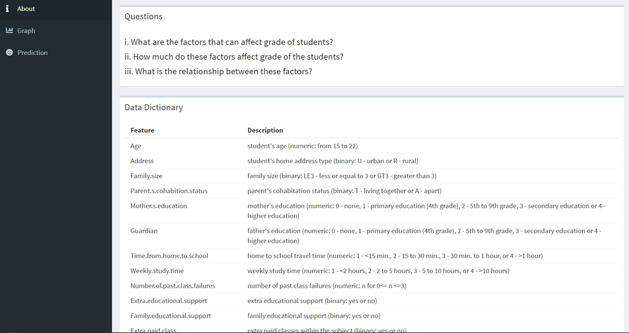

2. This is **“Graph”** tab showing for the scatter graph

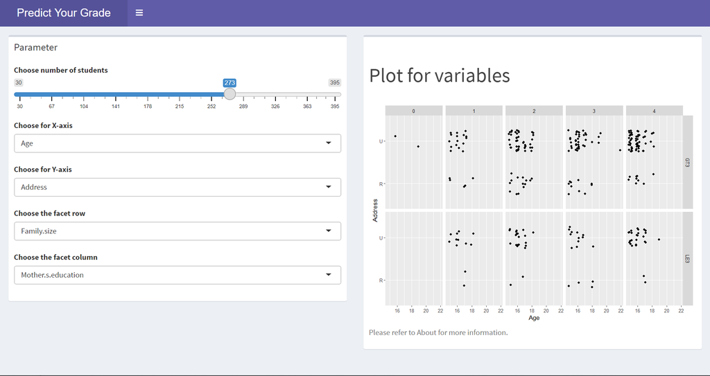

3. This is **“Predict”** tab showing for the prediction

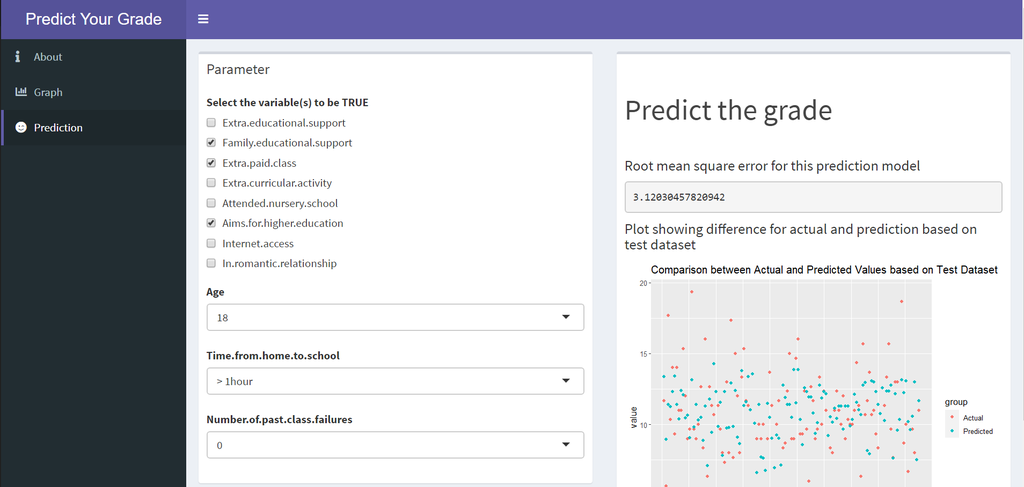

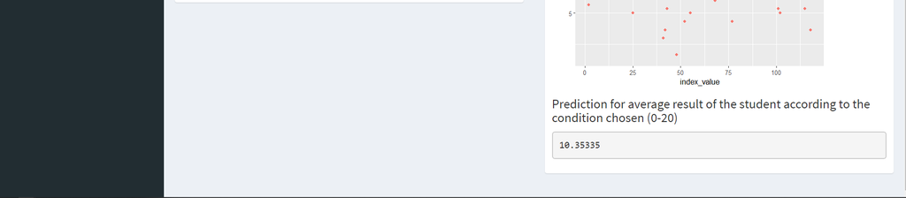

We have listed the factors that affect the grade of students in **“About”** tab, making some analysis and visualization for determining how factors affecting the grade as well as relationship between the factors in **“Graph”** tab. Further checking on extend factors affecting grade of students can be determined at **“Predict”** tab.

## Project experience

We learned lot on developing the data product, yet there are still some challenges faced by us in completing the assignment, and they are listed as shown:

1. Defining a good question for the project and finding and appropriate data set regarding the question
2. Inexperience in operation related to prediction and choosing appropriate prediction model
3. Communication with teammates is halted because of the online learning environment
4. Lack of experience in members in R programming language

## Conclusion

There are need for ensuring academic performance of the student to be improved, where this required more effort in determining factors affecting the students and solving them one by one. Suitable helps such as financial support or meeting with parents for further discussion on student’s daily life should be determined. This require attention from not only students, but also parents, school, government and even society since these students who will be leading the world in future and academic performance stands for capability of them.